# main

## Has the Paris Agreement made a difference?

*xxx*

Project for Python for Geoscience class

```python
import numpy as np
import pandas as pd
import matplotlib as mpl
import matplotlib.pyplot as plt
%matplotlib inline


# import cartopy
import cartopy
import cartopy.crs as ccrs
import cartopy.feature as cfeature
from cartopy.mpl.gridliner import LONGITUDE_FORMATTER, LATITUDE_FORMATTER

from shapely.geometry import Point, LineString
import geopandas as gpd

from matplotlib.ticker import AutoMinorLocator
```

### 1. Introduction

It’s widely recognised that carbon dioxide emissions are the primary driver of global climate change. To avoid the worst impacts of climate change, the world needs to urgently reduce emissions. At the 2015 United Nations Climate Change Conference near Paris, France, an international treaty on climate change was negotiated and passed by 196 parties. The treaty, called the Paris Agreement, covers climate change mitigation, adaptation, and finance.

Its goal is to limit global warming to well below 2, preferably to 1.5 degrees Celsius, compared to pre-industrial levels. To achieve this long-term temperature goal, countries aim to reach global peaking of greenhouse gas emissions as soon as possible to achieve a climate neutral world by mid-century.

Now, six years has passed and I'd like to examine if the agreement has made a difference or not.

### 3. Datasets

The estimates of global and national fossil are based on the the Global Carbon Project (GCP). Their dataset covers a period from 1750 to present and even subdivides emissions according to the sources (e.g., coal, oil, gas and so on). The buildup of the datasets starts from 2001, guaranteeing the data quality. The details it covered and the quality make this a perfect dataset to help realize my object.  
To visulize the global data, the country geometry of 110 meters resolution is used here. It's provided as class materials and the source is unclear.

### 4. Coding

#### 4.1 Data reading

```python
# read the data
# read the co2 emission data by country
emission = pd.read_csv('GCB2021v34_MtCO2_flat.csv',  encoding = "ISO-8859-1")  # default encoding method will cause an error here

# read the country geometry data
country = gpd.read_file("ne_110m_admin_0_countries")

# merge the emission and country geometry together
emission_with_geometry = pd.merge(left = emission,
                                 right = country.replace("United States of America", "USA"),
                                 left_on = 'Country',
                                 right_on = 'ADMIN')
# check the type
print("Initial dataset type: ", type(emission_with_geometry))

# convert to geopandas dataframe
# index with different methods for the convenience of grouping data in the next

emission_with_geometry_time = gpd.GeoDataFrame(emission_with_geometry.set_index('Year'), crs = 'EPSG:4326')
emission_with_geometry_country = gpd.GeoDataFrame(emission_with_geometry.set_index('Country'), crs = 'EPSG:4326')

print("After conversion: ",type(emission_with_geometry_time))
```

```
Initial dataset type:  <class 'pandas.core.frame.DataFrame'>
After conversion:  <class 'geopandas.geodataframe.GeoDataFrame'>
```

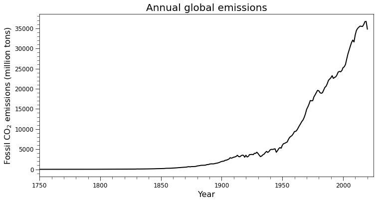

```python
# plot the global trend
emission_global = emission.set_index('Country')
emission_global_time_indexed = emission_global.loc['Global'].set_index('Year')

# plot the figure
fig, ax = plt.subplots(1, 1, figsize=(12,6))
ax.plot(emission_global_time_indexed.Total, lw = 2, color = 'black')


# ax settings

ax.set_ylabel('Fossil CO$_2$ emissions (million tons)',fontsize=16)
ax.set_xlabel('Year',fontsize=16)
ax.set_title('Annual global emissions', fontsize = 20)
ax.set_xlim(1750,2025)

# set axes labels and ticks
# ax.set_xlim(0,12.5)
# ax.set_ylim(0,36)
plt.xticks(fontsize=12);
plt.yticks(fontsize=12);

ax.xaxis.set_minor_locator(AutoMinorLocator())
ax.yaxis.set_minor_locator(AutoMinorLocator())
ax.tick_params(which="minor", axis="x", length = 5)
ax.tick_params(which="major", axis="x", length = 8)
ax.tick_params(which="minor", axis="y", length = 5)
ax.tick_params(which="major", axis="y", length = 8)
```

The figure shows that, prior to the Industrial Revolution, emissions were very low. Growth in emissions was still relatively slow until the mid-20th century. The datasets since 1950 are used here for fitting to represent the modern trend.

#### 4.2 Global emissions comparison

```python
emission_global_time_indexed.loc[1950:2015]
```

| Year | ISO 3166-1 alpha-3 | Total | Coal | Oil | Gas | Cement | Flaring | Other | Per Capita |
| --- | --- | --- | --- | --- | --- | --- | --- | --- | --- |
| 1950 | WLD | 6003.238189 | 3855.859103 | 1648.791183 | 353.120535 | 66.855153 | 73.624416 | NaN | 2.366805 |
| 1951 | WLD | 6379.755941 | 4059.651860 | 1742.875458 | 416.148459 | 75.703654 | 79.875260 | NaN | 2.468913 |
| 1952 | WLD | 6465.694232 | 4008.654195 | 1838.574177 | 447.043842 | 80.703664 | 85.363804 | NaN | 2.457634 |
| 1953 | WLD | 6647.727815 | 4043.288487 | 1952.671664 | 474.481964 | 89.482869 | 81.348030 | NaN | 2.482710 |
| 1954 | WLD | 6789.936494 | 4039.060204 | 2069.160472 | 501.299974 | 97.082533 | 77.612011 | NaN | 2.491860 |
| ... | ... | ... | ... | ... | ... | ... | ... | ... | ... |
| 2011 | WLD | 34468.451046 | 14781.224591 | 11337.210528 | 6377.915913 | 1343.287876 | 354.302880 | 274.509258 | 4.895256 |
| 2012 | WLD | 34974.075146 | 14949.696820 | 11499.118617 | 6507.532370 | 1377.853661 | 364.404561 | 275.469117 | 4.908072 |
| 2013 | WLD | 35283.025443 | 15042.879961 | 11586.005475 | 6552.317435 | 1438.773930 | 369.849064 | 293.199577 | 4.893229 |
| 2014 | WLD | 35534.442952 | 15062.902200 | 11632.233150 | 6660.134271 | 1493.852504 | 381.462844 | 303.857982 | 4.870874 |
| 2015 | WLD | 35496.406339 | 14718.202615 | 11881.130860 | 6785.934829 | 1437.304535 | 372.363911 | 301.469588 | 4.809943 |

66 rows × 9 columns

```python
def fit_measure_comparison(dataframe, label_name):
    # input:
    # dataframe: a dataset include the fossil emissions and the corresponding years, pandas dataframe, default time-indexed
    # label_name: the label for the dataset, Global or country name
    # function: calculate the difference between the projection and measured results.
    # output: a figure, projection values, measured values, difference
    fit = np.polyfit(dataframe.loc[1950:2015].index, dataframe.loc[1950:2015].Total, 3)
    timefit = np.arange(1950,2021)
    emission_fit = np.polyval(fit,timefit)

    # plot the figure

    fig = plt.figure(figsize=(10, 6))
    ax = fig.add_subplot(1,1,1)
    ax.plot(dataframe.loc[1950:].index,dataframe.loc[1950:].Total,lw = 2, color = "red", alpha = 1, label = "measured data")
    ax.plot(timefit, emission_fit, '--', lw = 2, color = 'orange', alpha = 1, label = '3rd order polynomial fit')
    ax.set_xlabel('Time (year)',fontsize=16)
    ax.set_ylabel('Fossil CO$_2$ emissions (million tons)',fontsize=16)
    ax.set_title(f'Measured data vs fitting results ({label_name})',fontsize = 20)

    # spines
    ax.spines['right'].set_visible(False)
    ax.spines['top'].set_visible(False)

    # legend
    ax.legend(fontsize = 'x-large', edgecolor = "white")

    plt.xticks(fontsize=12)
    plt.yticks(fontsize=12)

    measure_integral = dataframe.loc[2016:].Total.sum()
    projection_integral = np.sum(emission_fit[-5:])
    print(f"Projected {label_name} emissions from 2016 to 2020: ", f'{projection_integral:.0f}', " million tons")
    print(f"Measured {label_name} emissions froom 2016 to 2020: ", f'{measure_integral:.0f}', " million tons")
    delta = measure_integral-projection_integral

    return measure_integral, projection_integral, delta
```

```
Projected Global emissions from 2016 to 2020:  194728  million tons
Measured Global emissions froom 2016 to 2020:  179534  million tons
```

```
(179534.098772, 194727.7315093279, -15193.632737327891)
```

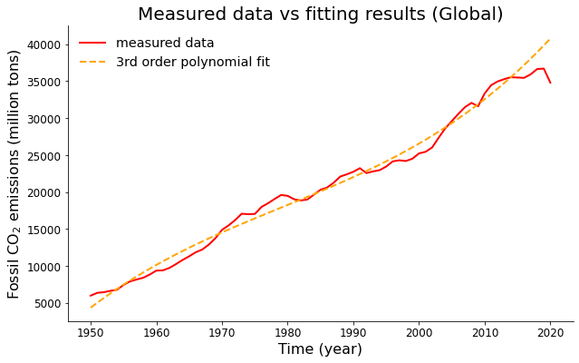

```python
fit_measure_comparison(emission_global_time_indexed, 'Global')
```

#### 4.3 The contribution of major countries

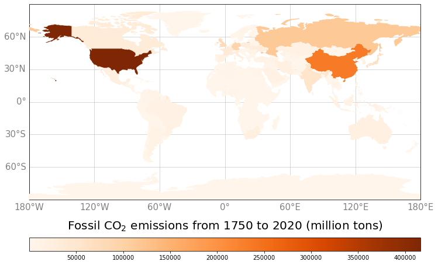

```python
# find out 5 countries with top total emissions
emission_total = emission_with_geometry_time.groupby(emission_with_geometry_time.Country).sum()

fig, ax = plt.subplots(figsize=(12, 12), subplot_kw={"projection": ccrs.PlateCarree()})

emission_total_with_geometry = pd.merge(left = emission_total,
                                 right = country.replace("United States of America", "USA"),
                                 left_on = 'Country',
                                 right_on = 'ADMIN')
emission_total_with_geometry.plot(ax = ax, column='Total', cmap='Oranges', zorder = 3)

gl = ax.gridlines(draw_labels=True,
                  linewidth=0.5,
                  x_inline=False,
                  y_inline=False,
                  xformatter=LONGITUDE_FORMATTER,
                  yformatter=LATITUDE_FORMATTER)

gl.xlabel_style = {'size': 15, 'color': 'gray'}  # control how the tick labels look
gl.ylabel_style = {'size': 15, 'color': 'gray'}
gl.top_labels = False  # turn off labels where you don't want them
gl.right_labels = False

# add colorbar
mappable = plt.cm.ScalarMappable(cmap='Oranges', norm=plt.Normalize(vmin=min(emission_total.Total), vmax=max(emission_total.Total)))

cb = fig.colorbar(mappable, ax=ax, orientation="horizontal", pad=0.1, shrink=1, aspect=30)

# # add the colorbar title
cb.set_label("Fossil CO$_2$ emissions from 1750 to 2020 (million tons)", fontsize=20, labelpad=-70)

# cb.ax.tick_params(axis='x',direction='in', labelsize=14, length=5, width=1)
```

```python
print("Total fossil CO$_2$ emissions from 1750 to 2020")
print(emission_total.Total.sort_values())
```

```
Total fossil CO$_2$ emissions from 1750 to 2020
Country
Antarctica              0.153888
Puerto Rico             0.208848
Vanuatu                 4.752294
Guinea-Bissau          10.094254
Solomon Islands        10.434984
                       ...
United Kingdom      78161.145636
Germany             92635.615097
Russia             115344.149534
China              235564.012528
USA                416723.089020
Name: Total, Length: 162, dtype: float64
```

So the top five countries are: United Kingdom, Germany, Russia, China, USA. Then I use the same method to test if their emissions have been influenced by the Paris Agreement.

```python
# get the data for each country
UK_emission = emission.set_index('Country').loc['United Kingdom'].set_index('Year').loc[1950:]
Ger_emission = emission.set_index('Country').loc['Germany'].set_index('Year').loc[1950:]
Rus_emission =  emission.set_index('Country').loc['Russia'].set_index('Year').loc[1950:]
Chi_emission =  emission.set_index('Country').loc['China'].set_index('Year').loc[1950:]
USA_emission =  emission.set_index('Country').loc['USA'].set_index('Year').loc[1950:]
```

```
Projected United Kingdom emissions from 2016 to 2020:  2260  million tons
Measured United Kingdom emissions froom 2016 to 2020:  1867  million tons
Projected Germany emissions from 2016 to 2020:  3935  million tons
Measured Germany emissions froom 2016 to 2020:  3696  million tons
Projected Russia emissions from 2016 to 2020:  6266  million tons
Measured Russia emissions froom 2016 to 2020:  8213  million tons
Projected China emissions from 2016 to 2020:  63104  million tons
Measured China emissions froom 2016 to 2020:  51089  million tons
Projected USA emissions from 2016 to 2020:  26870  million tons
Measured USA emissions froom 2016 to 2020:  25800  million tons
```

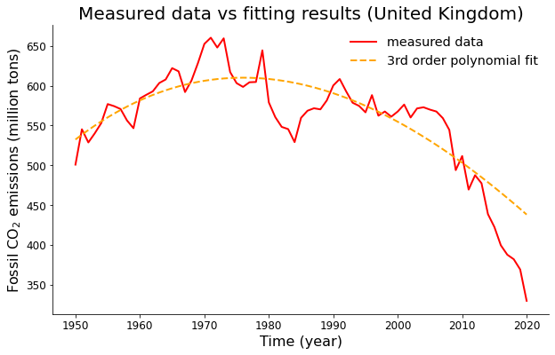

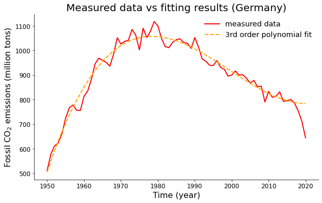

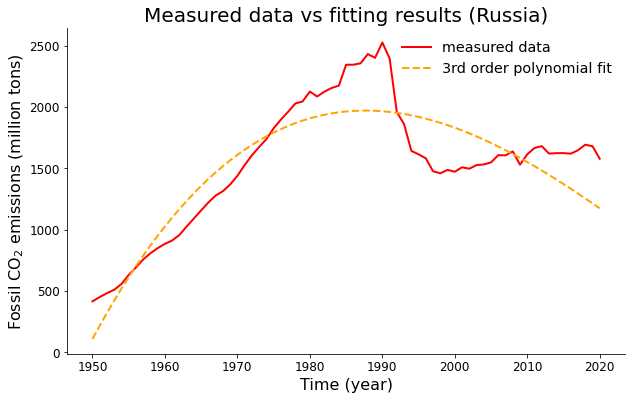

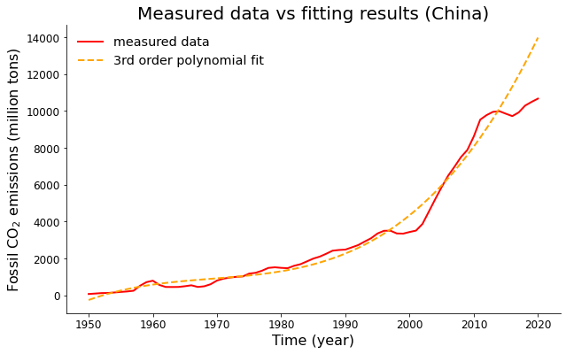

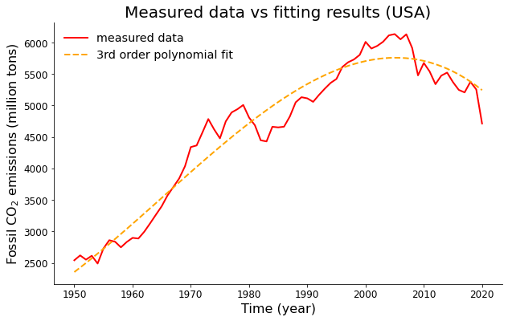

```python
pro_uk, inte_uk, delta_uk = fit_measure_comparison(UK_emission, 'United Kingdom')
pro_ger, inte_ger, delta_ger = fit_measure_comparison(Ger_emission, 'Germany')
pro_rus, inte_rus, delta_rus = fit_measure_comparison(Rus_emission, 'Russia')
pro_chi, inte_chi, delta_chi = fit_measure_comparison(Chi_emission, 'China')
pro_usa, inte_usa, delta_usa = fit_measure_comparison(USA_emission, 'USA')
```

[output not shown]

### 5. Conclusions

1. The Paris Agreement have made a difference, slowing down the growth of global fossil carbon emissions.
2. Except Russia, the top five major carbon contributors all have a lower emission value after 2015 than their previous trend suggests.
3. Our results are highly sensitive to the fitting method used for projection. Nevertheless, the function provided here will make it convenient for users to try other fitting methods.